# Investigating the Effect of Transmission Type on Fuel Economy

Zarni Maung

2026-05-25

## Executive Summary

This study elaborates data analysis, hypothesis testing, and constructing linear models to examine whether two transmission types (“Automatic” and “Manual”) impact fuel economy by utilising mtcars dataset. After analysis, results indicate that vehicles with manual transmission are more likely to results in better fuel efficiency in average, even after adding more independent variables.

## Explaratory data analysis

Initially, the following table shows the quick overview of mtcars dataset.

```r
head(mtcars)
```

|  | mpg | cyl | disp | hp | drat | wt | qsec | vs | am | gear | carb |
| --- | --- | --- | --- | --- | --- | --- | --- | --- | --- | --- | --- |
| Mazda RX4 | 21.0 | 6 | 160 | 110 | 3.90 | 2.620 | 16.46 | 0 | 1 | 4 | 4 |
| Mazda RX4 Wag | 21.0 | 6 | 160 | 110 | 3.90 | 2.875 | 17.02 | 0 | 1 | 4 | 4 |
| Datsun 710 | 22.8 | 4 | 108 | 93 | 3.85 | 2.320 | 18.61 | 1 | 1 | 4 | 1 |
| Hornet 4 Drive | 21.4 | 6 | 258 | 110 | 3.08 | 3.215 | 19.44 | 1 | 0 | 3 | 1 |
| Hornet Sportabout | 18.7 | 8 | 360 | 175 | 3.15 | 3.440 | 17.02 | 0 | 0 | 3 | 2 |
| Valiant | 18.1 | 6 | 225 | 105 | 2.76 | 3.460 | 20.22 | 1 | 0 | 3 | 1 |

According to the given dataset, mpg (miles per gallon) is treated as a dependent variable while transmission type (am) is an independent variable. As given per the dataset, 1 represents manual transmission, whereas, 0 means automatic. The initial analysis explores whether am affect mpg and examines the magnitude of the fuel efficiency difference between manual and automatic transmission. Firstly, mpg is compared with transmission group by illustrating boxplots:

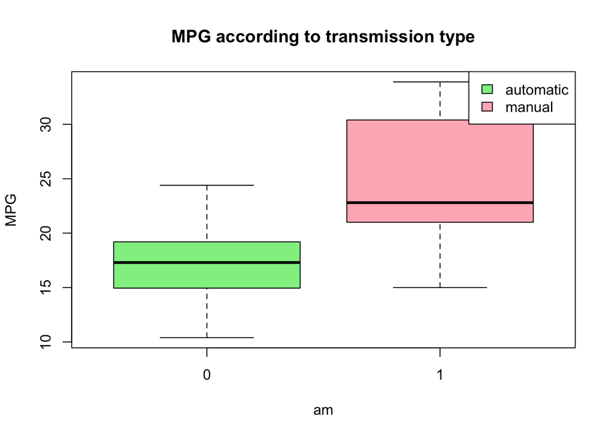

```r
boxplot(mpg ~ am,
        data = mtcars,
        col = c("lightgreen", "lightpink"),
        main = "MPG according to transmission type",
        ylab = "MPG")

legend("topright",
       legend = c("automatic", "manual"),
       fill = c("lightgreen", "lightpink"))
```

Hence, it is evident that manual transmission performs better fuel economy. If we compare their means:

```r
aggregate(mpg ~ am, data = mtcars, mean)
```

| am | mpg |
| --- | --- |
| 0 | 17.14737 |
| 1 | 24.39231 |

Thus, the mean fuel efficiency of vehicles with manual transmission (1) is significantly higher.

## Hypothesis Testing

There is an alternative way to test whether the transmission type impacts miles per gallon besides visualisation. We can examine by the scientific method of hypothesis testing. In this case, we apply t-test. The null hypothesis states that the transmission type has no effect on fuel efficiency. The test results are as follows:

```r
t.test(mpg ~ am, data = mtcars)
```

```
    Welch Two Sample t-test

data:  mpg by am
t = -3.7671, df = 18.332, p-value = 0.001374
alternative hypothesis: true difference in means between group 0 and group 1 is not equal to 0
95 percent confidence interval:
 -11.280194  -3.209684
sample estimates:
mean in group 0 mean in group 1
       17.14737        24.39231
```

Since the p-value is 0.001373638 (p < 0.05), we can reject our null hypothesis. The alternative hypothesis is that the transmission type does have an effect on fuel efficiency.

## Simple Linear Regression Analysis

Simple linear regression is started where mpg as dependent variable and am as a regressor.

```r
fit1 <- lm(mpg ~ am, data = mtcars)
summary(fit1)$coef
```

```
             Estimate Std. Error   t value     Pr(>|t|)
(Intercept) 17.147368   1.124603 15.247492 1.133983e-15
am           7.244939   1.764422  4.106127 2.850207e-04
```

According to
$$\hat{Y}_{\text{mpg}} =
\hat{\beta}_0 + \hat{\beta}_1 \cdot \text{am}$$
, automatic cars have estimated mpg of 17.15 while their manual counterparts shows estimated mpg of 24.39. Furthermore, :

```r
confint(fit1, level = 0.95)
```

```
               2.5 %   97.5 %
(Intercept) 14.85062 19.44411
am           3.64151 10.84837
```

We are 95% confident that the cars with manual transmission have on average, between 3.64 and 10.85 higher mpg, than automatic vehicles.

Therefore, the coefficient for manual transmission is statistically significant, however, we can input more independent variables to improve the model.

## Multiple Regression Analysis

The outcome mpg may not be impacted by transmission type alone. It can also be impacted by other characteristics of the car such as horsepower(hp), weight(wt), cylinders(cyl) and quarter-mile time(qsec). First, the regression model is fitted with all the independent variables.

```r
overall_fit <- lm(mpg ~ ., data = mtcars)
summary(overall_fit)
```

```
Call:
lm(formula = mpg ~ ., data = mtcars)

Residuals:
    Min      1Q  Median      3Q     Max
-3.4506 -1.6044 -0.1196  1.2193  4.6271

Coefficients:
            Estimate Std. Error t value Pr(>|t|)
(Intercept) 12.30337   18.71788   0.657   0.5181
cyl         -0.11144    1.04502  -0.107   0.9161
disp         0.01334    0.01786   0.747   0.4635
hp          -0.02148    0.02177  -0.987   0.3350
drat         0.78711    1.63537   0.481   0.6353
wt          -3.71530    1.89441  -1.961   0.0633 .
qsec         0.82104    0.73084   1.123   0.2739
vs           0.31776    2.10451   0.151   0.8814
am           2.52023    2.05665   1.225   0.2340
gear         0.65541    1.49326   0.439   0.6652
carb        -0.19942    0.82875  -0.241   0.8122
---
Signif. codes:  0 '***' 0.001 '**' 0.01 '*' 0.05 '.' 0.1 ' ' 1

Residual standard error: 2.65 on 21 degrees of freedom
Multiple R-squared:  0.869, Adjusted R-squared:  0.8066
F-statistic: 13.93 on 10 and 21 DF,  p-value: 3.793e-07
```

## Reduced Regression Model

Including all the possible regressors obviously overfit the data. Therefore, stepwise model selection will be adopted.

```r
step_model <- step(overall_fit, direction = "both")
```

```
Start:  AIC=70.9
mpg ~ cyl + disp + hp + drat + wt + qsec + vs + am + gear + carb

       Df Sum of Sq    RSS    AIC
- cyl   1    0.0799 147.57 68.915
- vs    1    0.1601 147.66 68.932
- carb  1    0.4067 147.90 68.986
- gear  1    1.3531 148.85 69.190
- drat  1    1.6270 149.12 69.249
- disp  1    3.9167 151.41 69.736
- hp    1    6.8399 154.33 70.348
- qsec  1    8.8641 156.36 70.765
<none>              147.49 70.898
- am    1   10.5467 158.04 71.108
- wt    1   27.0144 174.51 74.280

Step:  AIC=68.92
mpg ~ disp + hp + drat + wt + qsec + vs + am + gear + carb

       Df Sum of Sq    RSS    AIC
- vs    1    0.2685 147.84 66.973
- carb  1    0.5201 148.09 67.028
- gear  1    1.8211 149.40 67.308
- drat  1    1.9826 149.56 67.342
- disp  1    3.9009 151.47 67.750
- hp    1    7.3632 154.94 68.473
<none>              147.57 68.915
- qsec  1   10.0933 157.67 69.032
- am    1   11.8359 159.41 69.384
+ cyl   1    0.0799 147.49 70.898
- wt    1   27.0280 174.60 72.297

Step:  AIC=66.97
mpg ~ disp + hp + drat + wt + qsec + am + gear + carb

       Df Sum of Sq    RSS    AIC
- carb  1    0.6855 148.53 65.121
- gear  1    2.1437 149.99 65.434
- drat  1    2.2139 150.06 65.449
- disp  1    3.6467 151.49 65.753
```

[output cut: 72 more lines]

```
Step:  AIC=61.31
mpg ~ wt + qsec + am

       Df Sum of Sq    RSS    AIC
<none>              169.29 61.307
+ hp    1     9.219 160.07 61.515
+ carb  1     8.036 161.25 61.751
+ disp  1     3.276 166.01 62.682
+ cyl   1     1.501 167.78 63.022
+ drat  1     1.400 167.89 63.042
+ gear  1     0.123 169.16 63.284
+ vs    1     0.000 169.29 63.307
- am    1    26.178 195.46 63.908
- qsec  1   109.034 278.32 75.217
- wt    1   183.347 352.63 82.790
```

```r
summary(step_model)
```

```
Call:
lm(formula = mpg ~ wt + qsec + am, data = mtcars)

Residuals:
    Min      1Q  Median      3Q     Max
-3.4811 -1.5555 -0.7257  1.4110  4.6610

Coefficients:
            Estimate Std. Error t value Pr(>|t|)
(Intercept)   9.6178     6.9596   1.382 0.177915
wt           -3.9165     0.7112  -5.507 6.95e-06 ***
qsec          1.2259     0.2887   4.247 0.000216 ***
am            2.9358     1.4109   2.081 0.046716 *
---
Signif. codes:  0 '***' 0.001 '**' 0.01 '*' 0.05 '.' 0.1 ' ' 1

Residual standard error: 2.459 on 28 degrees of freedom
Multiple R-squared:  0.8497,    Adjusted R-squared:  0.8336
F-statistic: 52.75 on 3 and 28 DF,  p-value: 1.21e-11
```

Finally, the possible model with lowest model AIC is selected which contains regressors which are wt, qsec and am. Let’s construct the regression model for the selected model.

```r
fit <- lm(mpg ~ wt + qsec + am, data = mtcars)
summary(fit)
```

```
Call:
lm(formula = mpg ~ wt + qsec + am, data = mtcars)

Residuals:
    Min      1Q  Median      3Q     Max
-3.4811 -1.5555 -0.7257  1.4110  4.6610

Coefficients:
            Estimate Std. Error t value Pr(>|t|)
(Intercept)   9.6178     6.9596   1.382 0.177915
wt           -3.9165     0.7112  -5.507 6.95e-06 ***
qsec          1.2259     0.2887   4.247 0.000216 ***
am            2.9358     1.4109   2.081 0.046716 *
---
Signif. codes:  0 '***' 0.001 '**' 0.01 '*' 0.05 '.' 0.1 ' ' 1

Residual standard error: 2.459 on 28 degrees of freedom
Multiple R-squared:  0.8497,    Adjusted R-squared:  0.8336
F-statistic: 52.75 on 3 and 28 DF,  p-value: 1.21e-11
```

Hence, it is clear that the variable am is statistically significant impact on mpg.

## Residual Diagnostic Plot 1: Residuals vs Fitted

Let’s explore dignostic plots :

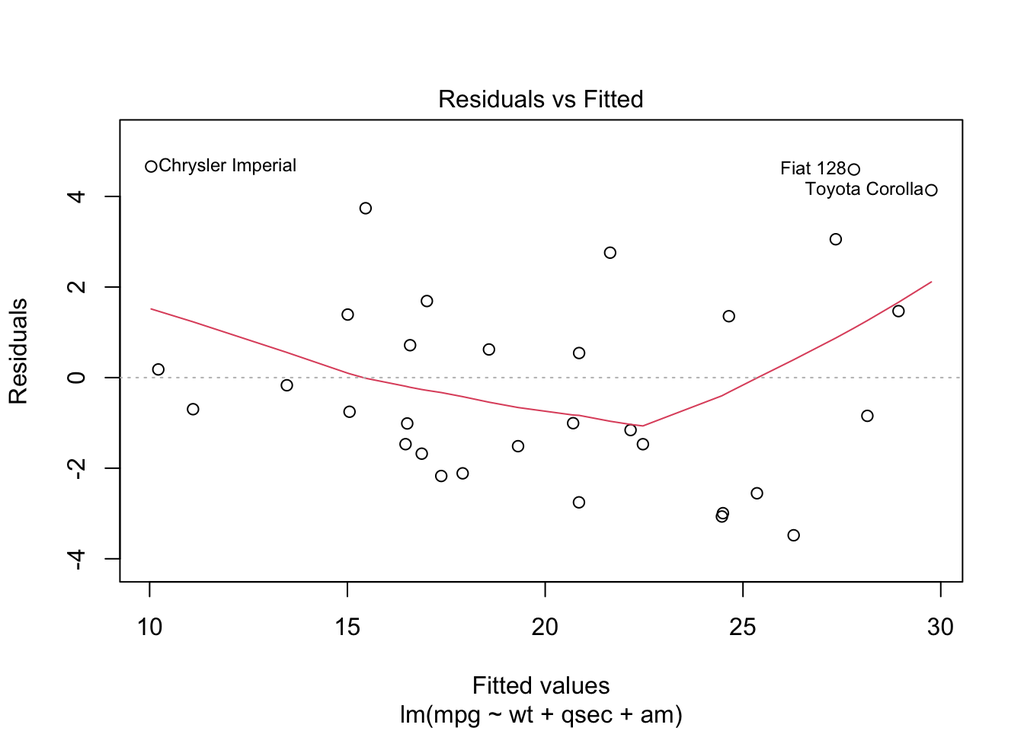

```r
plot(fit, which = 1)
```

## Residual Diagnostic Plot 2: Normal Q-Q

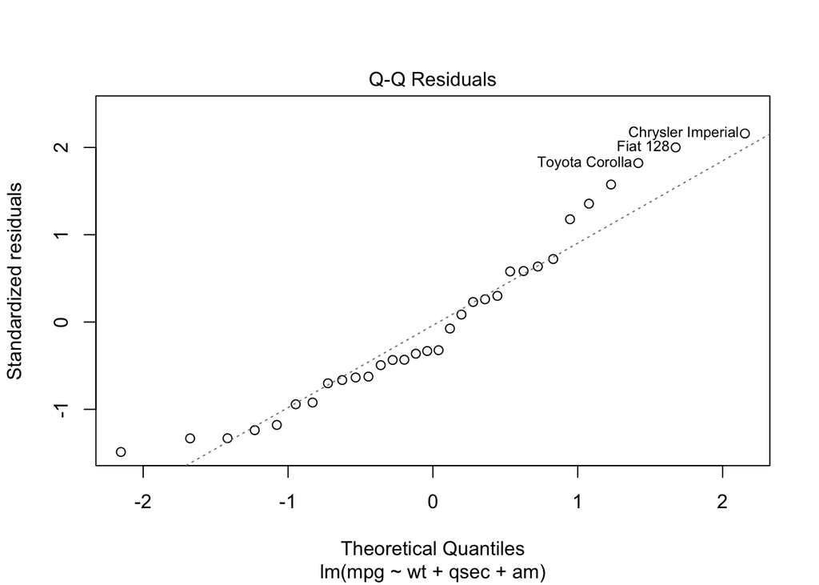

```r
plot(fit, which = 2)
```

The normal Q-Q plot compares the standardised residuals with regression model with the theoretical quantiles of normal distribution. If residuals follow normal distribution, they follow along the reference line. In this plot, the residuals follow the rule mentioned.